RELATIONAL ADVANTAGE · DIFFUSION

# Does Relational Advantage Travel Across Tasks?

Evidence from Microcredit Entry and Adoption

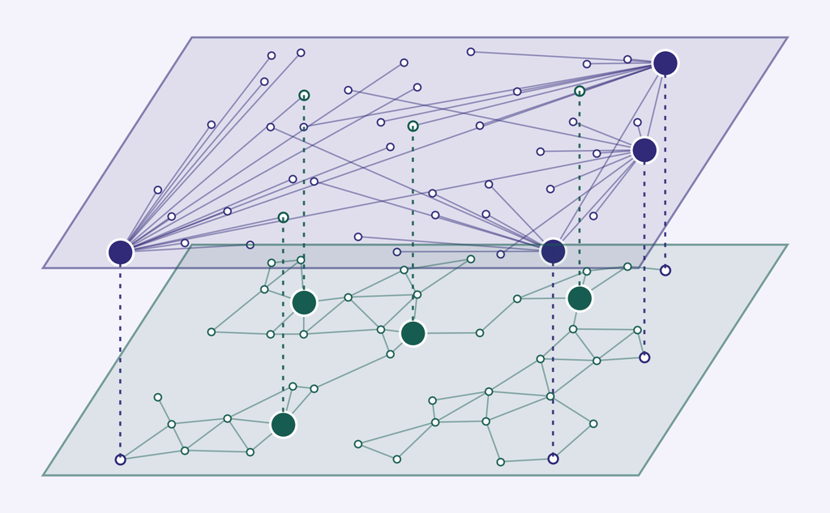

Roberto Cantillan

Department of Sociology · Pontificia Universidad Católica de Chile

## Who is selected—and who adopts?

The question

### Entry

An organization selects households as **entry points**.

### Adoption

Households decide whether to **commit** to a costly practice.

Does the relational advantage that helps at entry carry into adoption?

Katz & Lazarsfeld 1955 · Banerjee et al. 2013, 2019 · Beaman et al. 2021

## An opening matters through what follows

Diffusion as a sequence of accomplishments

An event acquires consequences through its connections to subsequent action.

### Entry

An opportunity arrives.

### Information

People become aware.

### Adoption

People decide to commit.

What connects one accomplishment to the next need not be the same relation.

Conceptual adaptation of Rule, Sabetta & Bearman (2026), “Pathways and Chance,” Sociologica, §4.

## Fixed networks. Successive tasks.

[figure not shown]

Two coexisting fixed relational domains connect the same six actors. Actor 1 is central in A and actor 2 in B. Successive tasks place more relevance on A and then B, illustrating a possible reversal in their relative advantage.

Conceptual illustration, not a simulation result. Both domains coexist; only task relevance changes.

## Relational advantage across tasks

01

The concept, its antecedents, and the conditions for reordering.

## Portability is continuity of relational advantage

The concept

An advantage is **portable** when the position that helps an actor at one task remains advantageous at the next.

A **relation** is a domain of ties, such as advice or visiting.

A **task** is an accomplishment needed for the process to advance. Organizations can perform selection; households can receive information or adopt.

We compare successive tasks within a process, with the actors’ positions held fixed.

## The premises we inherit—and the question we add

**Tasks can require different resources.** Learning, gaining access and committing need not draw on the same relations.

**Different networks can work together.** Their overlap and interaction shape diffusion; combining them can hide important differences.

**Network advantage depends on the task.** Hansen and colleagues show that a network beneficial for one task can hinder another.

We make continuity of relative advantage across successive tasks the object of explanation.

Coleman 1988 · Gould 1991 · Hansen et al. 2001 · Becker et al. 2020 · Chandrasekhar et al. 2026 · Distinctions: A1.

## Advantage depends on what the task values

Theory · A minimal formalization

For a task, add **position × relevance** across domains. The positions stay fixed; their relevance can change.

$$R_{ir}=\sum_l\omega_{lr}x_{il}.$$

$x_{il}$: actor $i$’s position in domain $l$. $\omega_{lr}$: how much task $r$ values that domain’s capacities.

$R_{ir}$ is a **theoretical score**. This minimal model adds fixed, comparable positions with nonnegative weights.

Hold the positions fixed. Change what the task values.

## Fixed positions; a different ordering

Theory · A minimal formalization

Actor 1 leads in A; actor 2 leads in B. Fixed positions can preserve or reverse the ordering, depending on the weight shift.

| Actor | Position A | Position B | Task 1 | Small shift | Large shift |
| --- | --- | --- | --- | --- | --- |
| **Actor 1** | .8 | .2 | **.68** | **.50** | .32 |
| **Actor 2** | .5 | .4 | .48 | .45 | **.42** |

**A’s weight:** .8 initially → .5 (small shift) or .2 (large shift). B receives the remainder.

The pair ties when A’s weight is .4. Crossing that threshold reverses the order.

## When does advantage persist—and when can it reverse?

**Similar task weights preserve the basis of advantage.** Exactly unchanged weights preserve the additive ordering.

**Ahead in every relevant domain:** an actor cannot fall strictly behind the same rival under nonnegative weights.

**Opposing domain advantages:** a task-weight shift can reverse the pair, if the shift is large enough to reverse their initial gap.

Changing tasks alone is insufficient: the change must matter for the actors’ relative profiles.

Additive benchmark with fixed, comparable positions · Exact pairwise criterion: A4.

## What would challenge this explanation?

Evidence needed · Distinguish a possibility from an explanation

Measure **task demands and domain resources independently of the outcomes**; follow the same actors across stages.

If relevance shifts toward domains where actors hold opposing advantages, ask whether those differences explain **who loses or gains relative advantage**.

Repeated conservation despite large, independently established shifts would challenge the proposed explanation. Reordering without a shift would call for **another mechanism**.

A change in domain associations motivates the explanation; a direct test must connect demands, positions, and individual outcomes.

## Pooling can hide a task-specific advantage

Conditional measurement implication

Domain-specific position preserves distinctions between relational infrastructures.

Union-network position pools ties before asking what the task requires.

When an adoption association is concentrated in a particular domain, pooling other relations can dilute that signal.

The value of aggregation depends on the task and on how actors’ positions correspond.

## Empirical design

02

Two datasets, distinct tasks, and comparable household networks.

## Different studies observe different stages

| Study | Unit and outcomes | Role |
| --- | --- | --- |
| **BSS · 49 villages, 10,618 households** | Household designation and own adoption | Within-setting stage comparison |
| **Information RCT · 68 villages** | Reach generated by randomized sets of 3 or 5 seeds | Information benchmark compared with BSS adoption |
| **Behavioral simulation** | Individual information and adoption probabilities | Sequential-process illustration |

**Designation is not information receipt.** BSS does not observe information; the simulation illustrates the general process rather than reconstructing the BSS sequence.

## Networks precede the arrival of microcredit

Setting · Karnataka, India

10,618

Households in the adoption analysis

49 / 75

Adoption villages / network villages

17.3%

Households that took up a BSS loan

- Networks measured in **2006**, about six months before entry.
- BSS designated **12%** of households using locally influential roles.
- Designation is **organizational selection**; adoption is the household’s own outcome.

Banerjee, Chandrasekhar, Duflo & Jackson 2013

## Nominations become comparable household networks

Network construction · BSS

**Nodes:** households on a common village roster.

**Ties:** combine each pair of name generators. A nomination in either direction creates one binary, undirected tie; self-ties are removed.

**Positions:** compute diffusion centrality separately in each domain, then scale it to $[0,1]$ within village and domain.

The same households and position measure allow comparisons across relations.

Diffusion centrality: Banerjee et al. (2013) · Intuition, example and implementation: Appendix A2–A2a.

## Centrality includes what your contacts can reach

Measurement · Diffusion centrality

Start a message at one household. Count transmission opportunities to **its contacts**, then through **their contacts**, for a finite number of rounds.

Weight each step by the transmission parameter $q$. A household with well-connected contacts can score higher than another with the same number of ties.

Compute this separately in each domain. **Repeated arrivals count.**

Degree counts immediate contacts. Diffusion centrality also counts onward transmission opportunities.

Banerjee et al. (2013), Eq. 5 · Appendix A2–A2a: intuition, worked example and implementation.

## The relations we observe

Measurement · The main comparison

| Domain | Reported ties |
| --- | --- |
| **Advice/Decision** | Advice and decision support |
| **Exchange** | Money lending and borrowing |
| **Visiting** | Visits to each other’s homes |

These are the focal domains. The SI also examines every remaining BSS relation.

Paired name generators; undirected layers · Alternative generators and domain composition: A7.

## Entry and adoption use identical comparisons

Design · Primary evidence

### Entry designation

Was the household in the lender’s **designated entry pool**?

### Own adoption

Did the household **take up a BSS loan**?

- The three domain positions enter **together** in each model.
- Compare households **within village**, with identical controls.
- Estimate the two equations jointly; cluster uncertainty by village.

Controls: union degree, wealth, and network-survey participation. Linear probability models. · Appendix A3: joint equations and contrast.

## Empirical evidence

03

Which domain is associated with entry—and which with adoption?

## Households rank differently across domains

Results · Positional differentiation

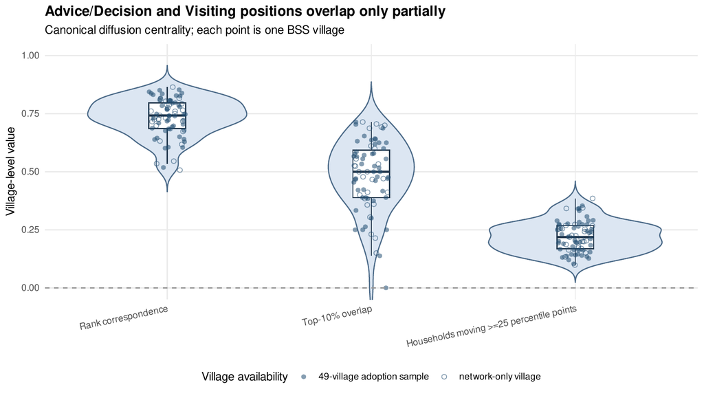

Cross-domain positional differentiation in the 75 Karnataka villages.

.742

Median rank correlation

50%

Top-decile overlap in the median village

21.8%

Move at least 25 percentile points

75 villages · Advice/Decision versus Visiting · Correlation IQR: .686–.796

## Observed pattern · Entry and adoption differ

Results · Same households, two outcomes

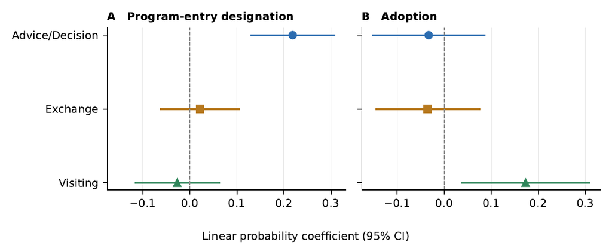

Coefficients for entry designation and adoption, with 95% confidence intervals.

**Entry:** Advice/Decision $b=0.219$, $p<.001$

**Adoption:** Visiting $b=0.173$, $p=.012$

10,618 households · 49 villages · All three domains in each model · Village-clustered 95% CIs

## The domain contrast changes sign

Results · Beyond a difference in significance

### Visiting minus Advice/Decision

**At entry:** $-0.246$  
**At adoption:** $+0.206$

Θ = 0.451

Change in the domain association contrast  
SE $0.103$ · $p<.001$

Moving from the 25th to the 75th percentile of Visiting position corresponds to **4.3 pp** more adoption.

Adoption base rate: 17.3%. Rounded domain gaps may differ slightly from the unrounded joint contrast. · Appendix A3: definition of the contrast.

## The Visiting association survives key checks

Results · Robustness

| Check | Result |
| --- | --- |
| **Leave one village out** | Visiting stays positive and significant in all **49** estimates. |
| **Exclude the entry pool** | Visiting $b=0.168$, $p=.025$. |
| **Small-cluster inference** | Visiting wild-cluster bootstrap $p=.021$. |
| **Alternative measurement** | All **8** reversal contrasts and **16** adoption domain contrasts are positive. |
| **Additional relational layers** | Visiting remains positive: $b=.148$–$.179$, all $p<.05$. |

Seven of eight reversal tests have p < .05; 15 of 16 adoption contrast intervals exclude zero.  
A5: rival explanations · A11: medical, temple, kin/nonkin and rice/kerosene layers (separate specifications).

## Visiting exceeds the union association

Results · Same sample and controls; separate one-measure models

### Union centrality

−0.025

Association with adoption  
SE $0.070$ · $p=.72$

### Visiting centrality

+0.156

Association with adoption  
$p=.030$

Visiting exceeds the union coefficient by **0.181** (SE $0.058$, $p=.003$).

Two single-measure models estimated jointly. Visiting .156 here; .173 in the joint three-domain model.

## The Visiting signal is concentrated in nearby ties

Results · Main qualification

### Nearby Visiting ties

+0.080

$p=.017$

### Other Visiting ties

+0.019

$p=.71$

Learning from neighbors and neighborhood differences in exposure remain competing explanations.

Near = within five positions in census enumeration order; 32.9% of Visiting ties. Location proxy, not coordinates. · Appendix A6: composition and secondary test.

## Benchmark · Information and adoption

**Information RCT:** 68 villages, randomized sets of 3 or 5 seeds.  
**BSS adoption:** 10,618 households in 49 other villages.

| Relational domain | Information · RCT | Own adoption · BSS |
| --- | --- | --- |
| Advice | .362 (.242) | .039 (.024) |
| Decision Support | −.214 (.123) | −.059 (.019) |
| Visiting | −.322 (.196) | .069 (.037) |
| Material exchange | .401 (.264) | .009 (.024) |
| **Visiting − Advice** | **−.684 (.325)** | **+.029 (.043)** |

Information favors Advice over Visiting. The adoption contrast is small and imprecise.

Joint four-layer models; predictors and outcomes in SD units; SEs in parentheses. RCT contrast: randomization p = .030. Different studies and units; no observed individual sequence across both stages.

## A sequential behavioral model

04

Fixed actors and layers; changing demands, access, and reinforcement.

## What is the model designed to explain?

Computational model · Purpose

**Question:** can changing the relevant domain reorder the same actors in a sequential information–adoption process?

**Comparison:** change adoption weights; keep the networks, initiators and informed population fixed.

**Mechanism:** task relevance changes contacts; information access and reinforcement generate individual outcomes.

**Aim:** examine its consequences and limits under explicit assumptions.

Follow individual advantage through the sequence, and separate task change from the baseline stage difference.

## Build two layers before changing the task

Computational model · Network construction

Generate **40 independent pairs**, each with **40 actors**, mean degree **6**, four groups and heterogeneous activity. Within-group pairs have four times the sampling weight.

Initially align the degree rankings in A and B. Relabel **0%, 50% or 100%** of B’s actors while preserving B’s topology.

Relabeling changes who occupies its positions and which cross-layer neighborhoods overlap. Aligned degrees do not make the layers identical.

## Fixed ties; changing task relevance

Model · Individual portability

Apply task weights to **ties**, rather than actor scores. The cascade then computes behavioral outcomes.

$$P_r=\beta_r[\omega_{Ar}A+(1-\omega_{Ar})B].$$

The weights come from section 01. $\beta_r$ sets contact intensity: **.4 for information; .8 for adoption**.

An A-only tie gets probability $\beta_r\omega_{Ar}$; a B-only tie gets $\beta_r(1-\omega_{Ar})$. A tie in both gets $\beta_r$.

The matching rule changes contact opportunities. Cascade outcomes are computed from the resulting paths and response rules.

## Information first; adoption second

Computational model · The process

01 · Information

### News travels

Three fixed initiators start the cascade. Newly informed actors can pass the news onward.

02 · Eligibility

### Keep who heard

Information finishes spreading. Hold that informed population fixed across adoption contrasts.

03 · Adoption

### Support accumulates

Reuse the initiators. Informed actors adopt after support from *h* distinct active neighbors; new adopters become sources.

Continue adoption until no actor changes state. Exclude the three forced initiators from individual rankings.

## Repeat the process; estimate each actor’s chances

Computational model · From cascades to individual rankings

Repeat the sequence to estimate **each actor’s own chances** of information, adoption and adoption given information.

| Illustrative actor, over 10 repetitions | Frequency |
| --- | --- |
| Receives information | 8 / 10 |
| Adopts through the full sequence | 4 / 10 |
| Adopts among occasions informed | 4 / 8 |

Since adoption requires information: $P(A_i)=P(I_i)\,P(A_i\mid I_i)$.

Illustrative counts only. Actual design: 64 information populations × 32 adoption contact worlds.

## Three comparisons answer different questions

Computational model · The process

| Comparison | What it asks |
| --- | --- |
| **Information vs adoption** | Do the same actors exchange places between stages? |
| **Changed vs unchanged adoption weights** | Do task weights change the adoption ordering, with the same eligibility and response-rule specification? |
| **Difference in between-stage reversal rates** | Does changing weights add more reversals, net of the unchanged-weight baseline? |

The net difference can be negative. A tie is recorded separately from a strict reversal.

## The experiments vary three dimensions

Model · Individual portability

| Dimension | Levels |
| --- | --- |
| **Functional differentiation** $s$ | 0 · 0.5 · 1 |
| **Adoption task demand** $\tau_2$ | Unchanged +1 · Partial 0 · Complete shift −1 |
| **Layer correspondence** | Aligned degree ranks · Partial relabeling · Full relabeling |

At $s=0$, a task shift leaves the mixture unchanged. At $s=1$, information uses A; adoption uses **A, an equal mixture, or B**. At $s=.5$, these shifts are moderated.

Paired task contrasts share layers, initiators, informed actors and contact uniforms. Design and exact controls: A8.

## Response rules answer different questions

Computational model · Response experiments

**Absolute:** require $h=1,2,3$ distinct supporting neighbors. The illustrative benchmark is $h=2$.

**Proportional:** require $\max(1,\lceil q\,k_{i,2}\rceil)$, where $k_{i,2}$ is weighted degree in the adoption layer. $q=.3,.4,.5$.

**Anchored:** use the same fractions of actor $i$’s degree in A; requirements remain fixed across adoption task contrasts.

Proportional rules change both contacts and requirements. Anchored and absolute contrasts hold requirements fixed.

## Simulation results

05

Individual reordering, response rules, and the limits of interpretation.

## Task shift adds reordering with two supports

Simulation results · Individual level

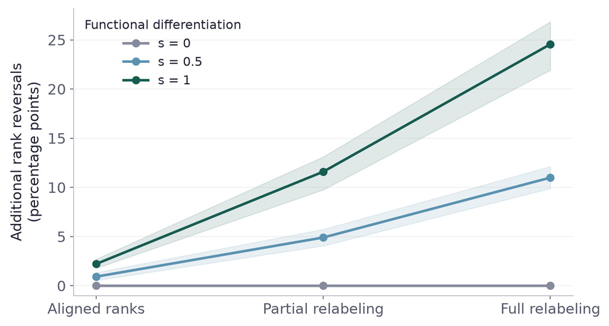

+24.6 pp

Net increase in information–adoption reversals.

**39 / 40 networks** show an increase.

Network-pair bootstrap interval: **21.9–26.8 pp**.

40 network pairs · h = 2 · Complete shift · Bands: network-pair bootstrap.  
Ranking stability with more Monte Carlo draws remains to be checked; full rules: A9.

## Adoption rankings change for the same actors

Simulation results · Individual level

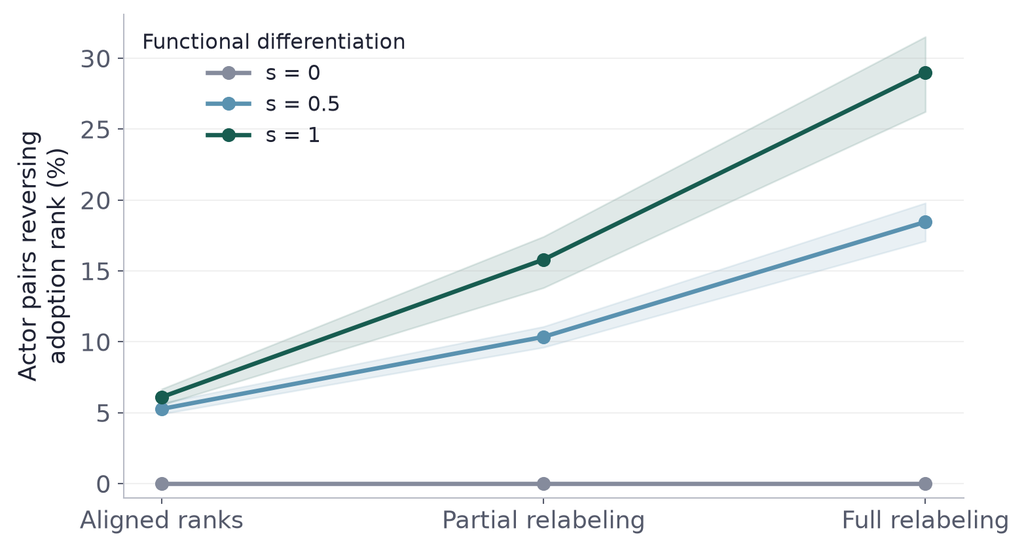

29.0%

Pairs reverse between unchanged and changed adoption weights.

Positions and initiators remain fixed.

40 synthetic network pairs · h = 2 · Complete task shift · Bands: bootstrap over network pairs.

## Reordering persists after information access

Simulation results · Individual level

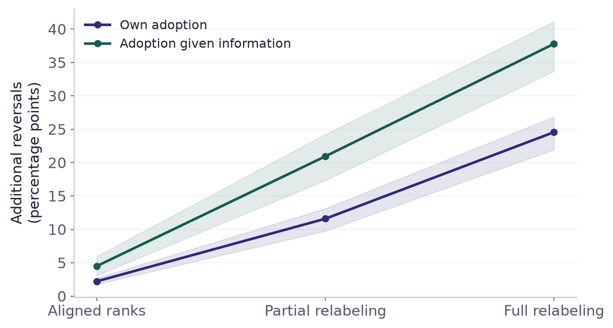

+37.8 pp

Net increase in reversals using adoption **given information**.

Access remains necessary; it need not preserve relative advantage.

40 synthetic network pairs · h = 2 · Complete task shift · Bands: bootstrap over network pairs.

## The domain associated with advantage changes

Simulation results · Individual level

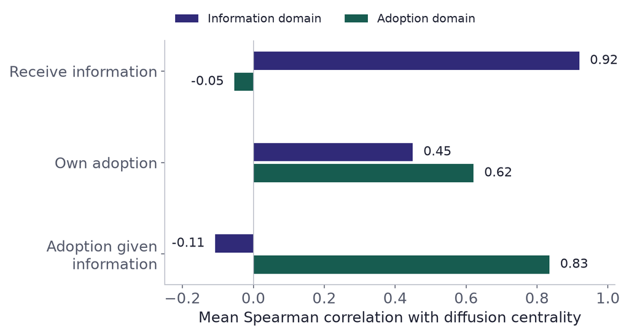

**Information** tracks position in A.

**Own adoption** tracks B more strongly.

A also remains associated with own adoption in this sequential process.

Mean within-network associations · Same nonforced actors · h = 2, s = 1, full relabeling.

## High requirements can flatten the ranking

Simulation results · Individual level

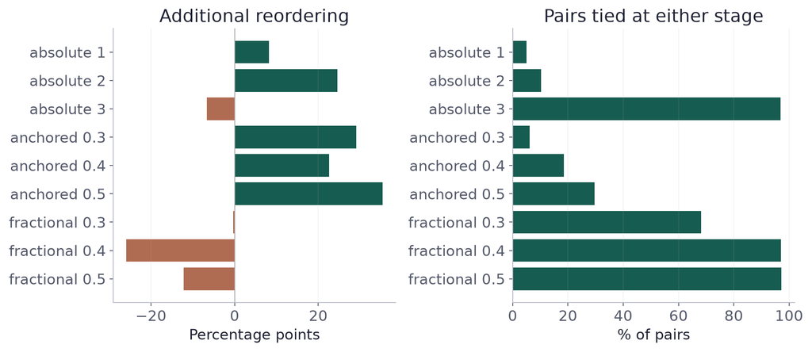

**h = 3:** almost no adoption after the shift.

About **97% of pairs are tied**, also at proportional 40%–50% requirements.

Fewer reversals can mean a collapsed ranking.

All nine response rules · Fixed requirements (anchored) and task-relative requirements (proportional). · Appendix A9: adoption, ties and all nine rules.

## Implications and scope

06

What follows from the evidence—and what remains to be established.

## What the evidence establishes—and leaves open

Interpretation

### Observed empirical pattern

Entry associates with **Advice/Decision**; own adoption with **Visiting**.

Union centrality has a weaker adoption association.

### Open explanation

Tie capacities are **not directly measured**.

Consultation may help interpret organizational selection. Observation, coordination or support may help interpret adoption. These are **possible, nonexclusive mechanisms**.

BSS compares designation and adoption associations. The model illustrates own probabilities; intervention reselection is a separate question (A10).

## Central in which relation—and for which task?

Discussion

Relational advantage can change  
as the process moves to its next task.

**Designation association**  
Advice/Decision

**Own-adoption association**  
Visiting

Roberto Cantillan  
Pontificia Universidad Católica de Chile

# Appendix

## A1 · Shared contacts, similar positions, portable advantage

| Question | What it describes |
| --- | --- |
| Do domains connect actors to the same people? | **Tie overlap** |
| Are the same actors prominent across domains? | **Positional correspondence** |
| Do actors retain their advantage at the next task? | **Portability of advantage** |

These are distinct questions. Changing what a task requires can reorder actors whose advantages lie in different domains.

Overlap and diffusion: Chandrasekhar et al. 2026 · Layer-switching: Min et al. 2016 · Targeting and network structure: Hsiao & Christakis 2026.

## A2 · Same degree; different onward opportunities

Consider a five-household chain: **1 — 2 — 3 — 4 — 5**.

Households **2 and 3 each have two direct contacts**. Their contacts offer different numbers of two-step walks.

| Contribution, using illustrative $q=.5$, $T=2$ | Household 2 | Household 3 |
| --- | --- | --- |
| One-step walks: $q \times 2$ | 1.00 | 1.00 |
| Two-step walks: $q^2 \times$ walk count | $.25\times3=.75$ | $.25\times4=1.00$ |
| **Total, before scaling and without $t=0$** | **1.75** | **2.00** |

Illustrative arithmetic, not the parameter choice used in estimation. Walks can return to their origin.

## A2a · Translate the intuition into the calculation

$$\mathrm{DC}(i)=\left[\sum_{t=0}^{T}(qA)^t\mathbf{1}\right]_i$$

**$A^t\mathbf{1}$ counts $t$-step walks from each household.** Multiplying by $q^t$ weights their transmission opportunities; the sum combines rounds.

**Our parameters:** $q=1/\lambda_{\max}(A)$; $T=$ layer diameter.

**Our scale:** minimum 0, maximum 1, within each village and domain.

Measure: Banerjee et al. (2013), Eq. 5 · Layer parameters: Chandrasekhar et al. (2026).  
The $t=0$ term adds a common constant, removed by min–max scaling.

## A3 · Joint outcome models and the reversal contrast

$$Y_{iv}^{k}=\alpha_v^k+\sum_{l\in\{AD,E,V\}}\beta_l^k\,\mathrm{DC}_{liv}+\mathbf{X}_{iv}'\gamma^k+\varepsilon_{iv}^k$$

$$\Theta=(\beta_V^U-\beta_{AD}^U)-(\beta_V^G-\beta_{AD}^G)$$

- **$G$:** designation; **$U$:** own uptake. Same sample and controls.
- **$\alpha_v^k$:** village fixed effects. Controls: union degree, wealth, survey participation.
- Joint estimation retains covariance across outcomes; uncertainty clustered by village.

## A4 · When do two actors exchange places?

$$(R_{i1}-R_{j1})(R_{i2}-R_{j2})<0.$$

Writing $R_{ir}=m_i+s\tau_r d_i$ gives:

$$\left(\Delta m_{ij}+s\tau_1\Delta d_{ij}\right)\left(\Delta m_{ij}+s\tau_2\Delta d_{ij}\right)<0$$

- **Common position:** $m_i=(x_{i1}+x_{i2})/2$.
- **Relational profile:** $d_i=(x_{i1}-x_{i2})/2$.
- $\Delta m_{ij}$ and $\Delta d_{ij}$ compare actors $i$ and $j$.
- A negative product means **opposite orderings** at the two tasks.

Different task scores do not necessarily imply different rankings.

## A4a · Matching weights

Theory · A minimal formalization

In two domains, advantage is a **weighted average of fixed, comparable positions**. This is the additive assumption.

$$\omega_{Ar}=\frac{1+s\tau_r}{2},\qquad \omega_{Br}=1-\omega_{Ar}.$$

**Domain differentiation $s$:** at $s=0$, both weights are always .5. Task demand cannot favor one domain over the other.

**Task demand $\tau_r$:** positive favors A, negative favors B. At $s=1$, demand can shift all the weight from A to B.

## A4b · The score-change identity

Theory · A minimal formalization

Subtract the same actor’s score at the two tasks:

$$R_{i2}-R_{i1}=\underbrace{\frac{s}{2}}_{\text{domain difference}}\;\underbrace{(\tau_2-\tau_1)}_{\text{task change}}\;\underbrace{(x_{iA}-x_{iB})}_{\text{position profile}}.$$

The change depends jointly on **different domain capacities**, **changed task demand**, and **where this actor stands across domains**.

If any factor is zero, this actor’s score stays the same. A changed score still need not change the ordering.

## A5 · Checks on rival explanations

| Threat | What could produce the pattern | What we do |
| --- | --- | --- |
| **General prominence** | Visiting just marks wealthier or more active households | Control union degree and wealth; compare opposite relational profiles after balancing on prominence; drop the entry pool |
| **Composition, homophily** | Caste structures both relations and access to credit | Sub-caste fixed effects; residualize on caste, religion, housing; estimate by caste |
| **Spatial proximity** | Visiting is local; nearby households may share exposure | Census enumeration order as a proxy; split Visiting ties into near and far |
| **Measurement** | Sampled respondents; composites; the pool is not the households contacted | Each constituent name generator; four scales; four sample restrictions |

A generic prominence account predicts the same positions have similar associations across tasks, not that different domains order them for different tasks.

## A6 · Composition and the secondary test

**Caste heterogeneity:** the adoption association is concentrated among lower-caste households (interaction $b=.159$, $p=.008$).

**Balanced relational profiles:** Visiting-oriented households adopt 2.4 pp more; interval $[-1.2,5.9]$.

**Cross-village moderation:** entry-pool advantage × domain divergence is imprecise ($b=-.008$, SE $.182$; $p=.96$).

These secondary comparisons locate the pattern; they do not independently establish the mechanism.

## A7 · Decision support versus advice: exploratory

- Separating the generators behind Advice/Decision: **Decision Support** centrality is negatively associated with adoption (standardized $b=-0.059$, $p=.003$).
- The *relative* profile matters: Decision Support minus Advice predicts lower adoption ($b=-0.099$, $p=.005$); their sum does not ($b=-0.020$, $p=.48$).
- Sharpest among entry-pool households (interaction $b=-0.074$, $p<.001$).
- The reversal is larger when Advice/Decision is represented by the decision generator (0.495 to 0.538) than by the advice generator (0.192 to 0.287).

Deliberative prominence as such does not predict lower adoption; ranking higher as a source of decision support than of advice does. **Outside the main comparisons and exploratory.**

## A8 · Sequential cascade design

Appendix · Computational specification

| Component | Fixed design |
| --- | --- |
| **Network pairs / actors / initiators** | 40 / 40 / 3 |
| **Information / adoption contacts** | 64 information populations / 32 adoption worlds each |
| **Transmission** | Information 0.4 / Adoption 0.8 |
| **Response rules** | h = 1, 2, 3; proportional and anchored q = .3, .4, .5 |
| **Controls** | Unchanged task; s = 0; identical layers |
| **Validation** | 6,480 exact null checks; reconstruction error 0 |

## A9 · All response rules retain their signed results

Appendix · s = 1, complete shift, full relabeling

| Rule | Adoption: no shift → shift | Tied pairs after shift | Extra reversals |
| --- | --- | --- | --- |
| absolute 1 | 82.6% → 79.4% | 5.0% | +8.2 pp |
| absolute 2 | 76.0% → 44.8% | 10.3% | +24.6 pp |
| absolute 3 | 7.9% → 0.4% | 97.0% | -6.7 pp |
| anchored 0.3 | 64.7% → 47.4% | 6.1% | +29.1 pp |
| anchored 0.4 | 10.6% → 21.4% | 18.6% | +22.6 pp |
| anchored 0.5 | 4.1% → 11.6% | 29.6% | +35.4 pp |
| proportional 0.3 | 64.7% → 5.7% | 68.1% | -0.4 pp |
| proportional 0.4 | 10.6% → 1.0% | 97.1% | -25.9 pp |
| proportional 0.5 | 4.1% → 1.0% | 97.2% | -12.2 pp |

## A10 · Collective gains depend on the specification

Appendix · Illustrative interventions on observed networks

| Observed-network scenario | Reselect gain | Gain relative to no-shift contrast |
| --- | --- | --- |
| **5% seeds · q=.3 · proportional** | +8.26 pp | +14.71 pp |
| **5% seeds · q=.3 · anchored** | −0.18 pp | +6.28 pp |
| **12% seeds · q=.4 · proportional** | +6.16 pp | +10.85 pp |
| **12% seeds · q=.4 · anchored** | −2.57 pp | +2.12 pp |

A positive task contrast can coexist with a negative reselection gain.

## A11 · Additional relations in the adoption models

Supplementary evidence

| Added relation | Added $b$ | $p$ | Visiting $b$ |
| --- | --- | --- | --- |
| Medical consultation | .004 | .898 | .173 |
| Temple co-presence | .030 | .285 | .175 |
| Temple + nonkin (nonkin term) | −.016 | .655 | .179 |
| Kinship | .058 | .097 | .169 |
| Rice/kerosene inflow | .107 | .048 | .148 |
| Rice/kerosene outflow | −.029 | .614 | .148 |

Every Visiting coefficient has p < .05. Inflow and outflow enter together; the other rows refer to separate specifications.

## Selected references · 1

- **Banerjee, A., Chandrasekhar, A. G., Duflo, E., & Jackson, M. O. (2013).** “The Diffusion of Microfinance.” *Science* 341(6144). doi:10.1126/science.1236498.
- **Banerjee, A., Chandrasekhar, A. G., Duflo, E., & Jackson, M. O. (2019).** “Using Gossips to Spread Information: Theory and Evidence from Two Randomized Controlled Trials.” *The Review of Economic Studies* 86(6):2453–2490. doi:10.1093/restud/rdz008.
- **Beaman, L., BenYishay, A., Magruder, J., & Mobarak, A. M. (2021).** “Can Network Theory-Based Targeting Increase Technology Adoption?” *American Economic Review* 111(6):1918–1943. doi:10.1257/aer.20200295.
- **Becker, S. O., Hsiao, Y., Pfaff, S., & Rubin, J. (2020).** “Multiplex Network Ties and the Spatial Diffusion of Radical Innovations: Martin Luther’s Leadership in the Early Reformation.” *American Sociological Review* 85(5):857–894. doi:10.1177/0003122420948059.

## Selected references · 2

- **Centola, D. & Macy, M. (2007).** “Complex Contagions and the Weakness of Long Ties.” *American Journal of Sociology* 113(3):702–734. doi:10.1086/521848.
- **Chandrasekhar, A. G., Chaudhary, V., Golub, B., & Jackson, M. O. (2026).** “Multiplexing in Networks and Diffusion.” *Proceedings of the National Academy of Sciences* 123(28). doi:10.1073/pnas.2534923123.
- **Hsiao, Y. & Christakis, N. A. (2026).** “The Influence “Paradox”: When More Network Ties Lead to Less Change.” *American Sociological Review* 91(3):464–489. doi:10.1177/00031224261438845.
- **Larson, J. M. & Rodríguez, P. L. (2023).** “The Risk of Aggregating Networks When Diffusion Is Tie-Specific.” *Applied Network Science* 8:21. doi:10.1007/s41109-023-00546-7.

## Selected references · 3

- **Omodei, E. & Arenas, A. (2016).** “Untangling the Role of Diverse Social Dimensions in the Diffusion of Microfinance.” *Applied Network Science* 1(1):14. doi:10.1007/s41109-016-0016-x.
- **Rule, A., Sabetta, L., & Bearman, P. (2026).** “Pathways and Chance.” *Sociologica* 20(1). doi:10.60923/issn.1971-8853/23641.
- **Min, B., Gwak, S.-H., Lee, N., & Goh, K.-I. (2016).** “Layer-switching cost and optimality in information spreading on multiplex networks.” *Scientific Reports* 6:21392. doi:10.1038/srep21392.
- **Valente, T. W. & Davis, R. L. (1999).** “Accelerating the Diffusion of Innovations Using Opinion Leaders.” *The ANNALS of the American Academy of Political and Social Science* 566(1):55–67. doi:10.1177/000271629956600105.

## Selected references · 4

- **Katz, E. & Lazarsfeld, P. F. (1955).** *Personal Influence: The Part Played by People in the Flow of Mass Communications.* Free Press.
- **Coleman, J. S. (1988).** “Social Capital in the Creation of Human Capital.” *American Journal of Sociology* 94:S95–S120. doi:10.1086/228943.
- **Gould, R. V. (1991).** “Multiple Networks and Mobilization in the Paris Commune, 1871.” *American Sociological Review* 56(6):716–729. doi:10.2307/2096251.

## Selected references · 5

- **White, H. C. (2008).** *Identity and Control: How Social Formations Emerge.* 2nd ed. Princeton University Press.
- **McAdam, D. (1986).** “Recruitment to High-Risk Activism: The Case of Freedom Summer.” *American Journal of Sociology* 92(1):64–90. doi:10.1086/228463.
- **Cai, J., de Janvry, A., & Sadoulet, E. (2015).** “Social Networks and the Decision to Insure.” *American Economic Journal: Applied Economics* 7(2):81–108. doi:10.1257/app.20130442.